[figure not shown]

# ELEC-D7010 Engineering for Humans

**Aurélien Nioche**

Aalto University

# Lecture 9 - Experimental Methods

# Define a research problem & the hypothesis

The research problem constitutes the **question(s)** you aim to answer.

The hypothesis constitute(s) the **answer(s)** to this(these) possible question(s).

## Important

Strong restriction: the hypothesis has to be a **falsifiable** statement ([Popper](https://plato.stanford.edu/entries/popper/), 1959 as a response to the problem of induction of [Hume](https://plato.stanford.edu/entries/hume/), 1739-40)

For a contextualized explanation, you can refer to the [Stanford Encyclopedia](https://plato.stanford.edu/entries/scientific-method/#PopFal): Andersen, Hanne and Brian Hepburn, "Scientific Method", The Stanford Encyclopedia of Philosophy (Summer 2016 Edition), Edward N. Zalta (ed.), URL = https://plato.stanford.edu/archives/sum2016/entries/scientific-method/.

H: "All swans are white"

[figure not shown]

H: "Most people do not really want freedom, because freedom involves responsibility, and most people are frightened of responsibility."

Is this statement falsifiable?

Examples of **non falsifiable statements**:

- **tautologies**
- **vague open-ended statements**

*Note: do not cofound *working* hypothesis and *testing* hypothesis*

## Important

Be aware of the **confirmation** bias

[figure not shown]

...but even using a scientific method, we can be tempted...

[figure not shown]

# Operationalize

> **Operationalize**: express or define (something) in terms of the operations used to determine or prove it.

## Important

Differentiate **dependant** and **independant** variable

- dependant: what we **measure**
- independant : what we **manipulate**

Let's take an example: **The swipe typing keyboard**

[figure not shown]

- What is in this case our research problem?
- What are the hypothesis we can draw?
- What are the dependant variable?
- what are the independant variable?

*Note: they can be several dependant and independant variables*

An **experiment** is a **comparison**, so...

## Important

Choose carefully your **baseline** and your **control**, in order to have interpretable results.

Why it is important?

Let's take an example...

...the [Mozart effect](https://www.nature.com/articles/365611a0)

[figure not shown]

# Choose the experimental design

## Important

Differentiate:

- **between** subjects design
- **within** subjects design

*For a comparison, see for instance [Charness et al. (2012). Experimental methods: Between-subject and within-subject design. *Journal of Economic Behavior & Organization*.</a>](https://rady.ucsd.edu/docs/faculty/Gneezy_jebo_between.pdf)*

To make it short...  
Do you expect large variability in your subjects?

- **No**: between subjects
- **Yes**: whithin subjects

If you choose "**yes**", be aware of possible [**counfound factors**](https://dictionary.apa.org/confound):

- [order effect](https://dictionary.apa.org/order-effect)

# Collect the data

## Important

Choose carefully your **sample**, i.e., be aware of **selection bias**

Even where you would not have expect them, a lot of differences can come from (arbitrary order):

1. **age**
2. **gender**
3. **cultural background / ethnicity**
4. **education**
5. level of **expertise** of X or Y than can interfere with your experimental task

Why it is important?

Let's take an example...

[figure not shown]

You should definitely look at [Heinrich et al. (2010). The weirdest people in the world? Behavioral and Brain Sciences.](https://doi.org/10.1017/S0140525X0999152X), or in a very short version [Heinrich et al. (2010). Most people are not WEIRD. Nature.](https://www.nature.com/articles/466029a?page=9)

# Analyze and interpret the data

How to go from **observations** to **interpretations** to answer (or contributes to the understanding to) your **research problem**

## Important

Look at your **raw data first**

Why it is important?

Let's take an example...

```python
# Import the libraries
import pandas as pd
import os
import seaborn as sns
import matplotlib.pyplot as plt
import numpy as np
import scipy.stats as stats
import scipy.special as sps  # For gamma function
```

```python
# Load the data
df = pd.read_csv(
    os.path.join("data", "circle-data.csv"),
    index_col=[0])

# Print the top of the file
print(df.head())
```

```
           x          y
0  53.500480  82.351329
1  50.629577  84.715953
2  49.932717  79.284252
3  48.788095  81.244959
4  49.496214  78.992123
```

You could be tempted to begin to compute descriptive statistics such as mean instead of looking to your data...

```python
# For both variables
for var in "x", "y":

    # Compute the mean and variance and print the result
    print(f"Mean '{var}': {np.mean(df[var])} +/- {np.std(df[var])} STD")
```

```
Mean 'x': 54.2697860735676 +/- 16.702413296753157 STD
Mean 'y': 47.83046573569003 +/- 26.836276834090196 STD
```

TLDR: let's change the precision...

```python
# For both variables
for var in "x", "y":

    # Compute the mean and variance and print the result showing only 2 digits after the comma
    print(f"Mean '{var}': {np.mean(df[var]):.2f} +/- {np.std(df[var]):.2f} STD")
```

```
Mean 'x': 54.27 +/- 16.70 STD
Mean 'y': 47.83 +/- 26.84 STD
```

And still without looking at the raw data, let's do a barplot:

```python
# Let's flip the dataframe (inverse row and columns)
df_flipped = df.melt()

# Print the top of the dataframe
print(df_flipped.head())
```

```
  variable      value
0        x  53.500480
1        x  50.629577
2        x  49.932717
3        x  48.788095
4        x  49.496214
```

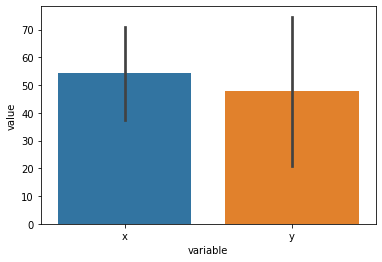

```python
# Do a barplot
sns.barplot(x="variable", y="value", data=df_flipped, ci="sd")

plt.show()
```

Let's consider a second dataset...

```python
# Load the data
df_other = pd.read_csv(
    os.path.join("data", "dino-data.csv"),
    index_col=[0])

# Look at the top of the file
print(df_other.head())
```

```
         x        y
0  55.3846  97.1795
1  51.5385  96.0256
2  46.1538  94.4872
3  42.8205  91.4103
4  40.7692  88.3333
```

```python
# For both variables...
for var in ("x", "y"):

    # Print the means and variances for the original dataset
    print(f"Original dataset - Mean '{var}': {np.mean(df[var]):.1f} +/- {np.std(df[var]):.2f} STD")
print()

# For both variables...
for var in ("x", "y"):

    # Print the means and variances for the second dataset
    print(f"Other dataset - Mean '{var}': {np.mean(df_other[var]):.1f} +/- {np.std(df_other[var]):.2f} STD")
```

```
Original dataset - Mean 'x': 54.3 +/- 16.70 STD
Original dataset - Mean 'y': 47.8 +/- 26.84 STD

Other dataset - Mean 'x': 54.3 +/- 16.71 STD
Other dataset - Mean 'y': 47.8 +/- 26.84 STD
```

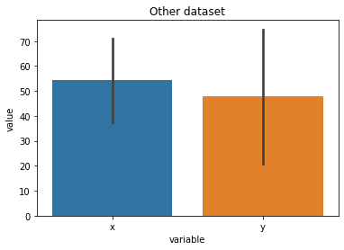

```python
# Do a barplot
sns.barplot(x="variable", y="value", data=df_other.melt(), ci="sd")

# Write a title
plt.title("Other dataset")

plt.show()
```

They look quite alike, isn't it?

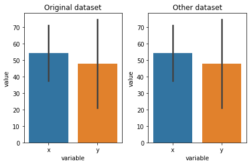

```python
# Create figure and axes
fig, axes = plt.subplots(ncols=2)

# Dot the left barplot
sns.barplot(x="variable", y="value", data=df.melt(), ax=axes[0], ci="sd")
# Set the title
axes[0].set_title("Original dataset")

# Do the right barplot
sns.barplot(x="variable", y="value", data=df_other.melt(), ax=axes[1], ci="sd")
# Set the title
axes[1].set_title("Other dataset")

plt.tight_layout()
plt.show()
```

However...

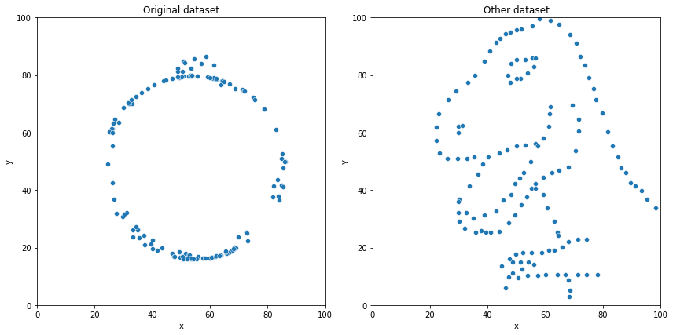

```python
# Create figure and axes
fig, axes = plt.subplots(ncols=2, figsize=(12, 9))


# For both dataset
for i, (label, data) in enumerate((("Original dataset", df), ("Other dataset", df_other))):

    # Do a scatter plot
    ax = axes[i]
    sns.scatterplot(x="x", y="y", data=data, ax=ax)

    # Set the title
    ax.set_title(label)

    # Set the limits of the axes
    ax.set_xlim(0, 100)
    ax.set_ylim(0, 100)

    # Make it look square
    ax.set_aspect(1)

plt.tight_layout()
plt.show()
```

A few more like this:

[figure not shown]

*Note: you can find a lot of astonishing examples in [Matejka, J., & Fitzmaurice, G. (2017, May). Same stats, different graphs: generating datasets with varied appearance and identical statistics through simulated annealing. In Proceedings of the 2017 CHI Conference on Human Factors in Computing Systems (pp. 1290-1294).](https://www.autodeskresearch.com/publications/samestats)*

## Compute descriptive statistics

...and only thereafter summarize the information, computing descriptive statistics: mean, median, standard deviation or standard error, ...

## Important

Differenciate **mean** and **median**

\begin{equation} \mathrm {median} (x)={\frac {1}{2}}(x_{\lfloor (n+1)/2\rfloor }+x_{\lceil (n+1)/2\rceil }) \end{equation}

where $x$ is an ordered list of $n$ numbers, and $ \lfloor \cdot \rfloor $ and $\lceil \cdot \rceil $ denote the floor and ceiling functions.  
The floor function is the function that takes as input a real number $i$, and gives as output the greatest integer less than or equal to $i$. Similarly, the ceiling function maps $i$ to the least integer greater than or equal to $i$.

Example ($n$ is odd): 1, 3, 3, 6, 7, 8, 9

Example ($n$ is even): 1, 3, 6, 7, 8, 9

\begin{equation}\mathrm{mean}(x) ={\frac {1}{n}}\left(\sum _{i=1}^{n}{x_{i}}\right)={\frac {x_{1}+x_{2}+\cdots +x_{n}}{n}} \end{equation}

where x is an ordered list of n numbers

Why is it important?

Let's take an example!

Let's considerate data $D_N$ that follows a normal distribution, that is such that:

$$ D_N\sim \mathcal{N} (\mu ,\sigma )$$$$ f(x)={\frac {1}{\sigma {\sqrt {2\pi }}}}e^{-{\frac {1}{2}}\left({\frac {x-\mu }{\sigma }}\right)^{2}}$$

```python
# Seed the random number generator
np.random.seed(123)

# Set the parameters
mu = 0
sigma = 100.0
n = 1000

# Generate a sample
data = np.random.normal(mu, scale=sigma, size=n)

# Print a few values
print("data (3 first values):", data[:3])
```

```
data (3 first values): [-108.56306033   99.73454466   28.29784981]
```

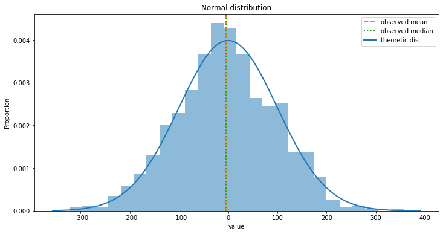

```python
# Create figure and axes
fig, ax = plt.subplots(figsize=(12, 6))

# Create an histogram
sns.histplot(x=data, kde=False, stat="density", ax=ax, linewidth=0, alpha=0.5)

# Plot lines for mean and median
ax.axvline(np.mean(data), label="observed mean", color='C1', lw=2, ls='--')
ax.axvline(np.median(data), label="observed median", color='C2', lw=2, ls=':')

# Represent the theoretic distribution
x = np.linspace(*ax.get_xlim(), 1000)
y = 1/(sigma * np.sqrt(2 * np.pi)) * np.exp( - (x - mu)**2 / (2 * sigma**2) )
ax.plot(x, y, linewidth=2, color='C0', label="theoretic dist")

# Set the title
ax.set_title("Normal distribution")

# Set the axis labels
ax.set_ylabel("Proportion")
ax.set_xlabel("value")

# Create the legend
plt.legend()

plt.show()
```

Let's now consider data $D_G$ that follows a Gamma distribution, that is such that: $$ D_G \sim \mathrm{Gamma} (\alpha ,\beta )$$ the probability density function of the Gamma distribution being : $${\begin{aligned}f(x;\alpha ,\beta )&={\frac {\beta ^{\alpha }x^{\alpha -1}e^{-\beta x}}{\Gamma (\alpha )}}\quad {\text{ for }}x>0\quad \alpha ,\beta >0,\\[6pt]\end{aligned}}$$ where $\Gamma (\alpha )$ is the gamma function. For all positive integers, $ \Gamma (\alpha )=(\alpha -1)!$

```python
# Seed the random number generator
np.random.seed(124)

# Set the parameters
# From the doc: Samples are drawn from a Gamma distribution with specified parameters,
# shape (sometimes designated “k”) and scale (sometimes designated “theta”),
# where both parameters are > 0.
# knowing that theta = 1/beta
shape = 1
scale = 1000
n = 1000

# Generate a sample
data = np.random.gamma(shape, scale=scale, size=n)

# Print a few values
print("data (3 first values):", data[:3])
```

```
data (3 first values): [ 112.12210818 1368.3424056   849.36491408]
```

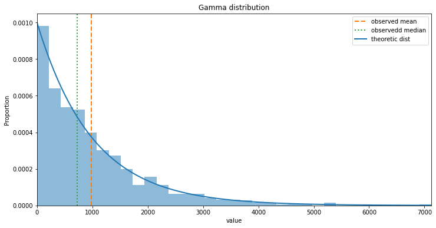

```python
# Create figure and axis
fig, ax = plt.subplots(figsize=(12, 6))

# Plot a histogram
sns.histplot(x=data, kde=False, stat="density", ax=ax, alpha=0.5, lw=0)

# Plot the lines representing the observed mean an median
ax.axvline(np.mean(data), label="observed mean", color='C1', lw=2, ls='--')
ax.axvline(np.median(data), label="observedd median", color='C2', lw=2, ls=':')

# Set the limits of the x-axis
ax.set_xlim(0, np.max(data))

# Represent the theoretic distribution
x = np.linspace(*ax.get_xlim(), 1000)
y = x**(shape-1)*(np.exp(-x/scale) /  (sps.gamma(shape)*scale**shape))
ax.plot(x, y, linewidth=2, color='C0', label="theoretic dist")

# Set the axis labels
ax.set_ylabel("Proportion")
ax.set_xlabel("value")

# Set the title
ax.set_title("Gamma distribution")

# Create the legend
ax.legend()

plt.show()
```

## Important

Always represent a **dispersion** measure of your data (e.g., standard deviation)

Why is it important?

Let's see an example...

```python
# Seed the random number generator
np.random.seed(4)

# Set the parameters
mean_1 = 150.0
mean_2 = 200.0

small_std = 10.0
large_std = 50.0

n = 100
```

```python
# Create the samples
val1_small_std = np.random.normal(mean_1, scale=large_std, size=n)
val2_small_std = np.random.normal(mean_2, scale=large_std, size=n)

val1_large_std = np.random.normal(mean_1, scale=small_std, size=n)
val2_large_std = np.random.normal(mean_2, scale=small_std, size=n)

# Print a few values
print("val1_small_std (3 first values):", val1_small_std[:3])
print("val2_small_std (3 first values):", val2_small_std[:3])
print("val1_large_std (3 first values):", val1_large_std[:3])
print("val2_large_std (3 first values):", val2_large_std[:3])
```

```
val1_small_std (3 first values): [152.52808536 174.99756666 100.20455344]
val2_small_std (3 first values): [236.91235556 232.53766155 230.73703148]
val1_large_std (3 first values): [145.27337184 150.96267944 162.29213395]
val2_large_std (3 first values): [211.9451626  195.01279275 199.19260386]
```

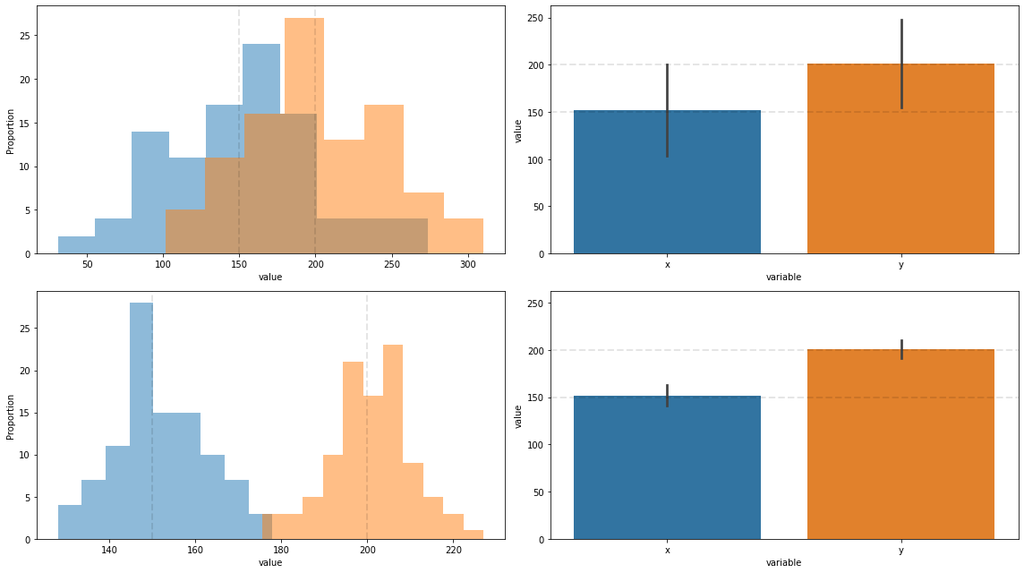

```python
# Create figure and axes
fig, axes = plt.subplots(ncols=2, nrows=2, figsize=(16, 9))

# For each dataset (containing each two samples)
for i, (val1, val2) in enumerate(((val1_small_std, val2_small_std), (val1_large_std, val2_large_std))):

    # Create histograms
    ax = axes[i, 0]
    sns.histplot(x=val1, ax=ax, color="C0", kde=False, alpha=0.5, lw=0)
    sns.histplot(x=val2, ax=ax, color="C1", kde=False, alpha=0.5, lw=0)

    # Plot the theoretical mean
    ax.axvline(mean_1, ls='--', color='black', alpha=0.1, lw=2)
    ax.axvline(mean_2, ls='--', color='black', alpha=0.1, lw=2)

    # Set the axis lables
    ax.set_ylabel("Proportion")
    ax.set_xlabel("value")

    # Create a barplot
    ax = axes[i, 1]
    df = pd.DataFrame({"x": val1, "y": val2}).melt()
    sns.barplot(x="variable", y="value", ax=ax, data=df, ci="sd")

    # Add horizontal lines representing the means
    ax.axhline(mean_1, ls='--', color='black', alpha=0.1, lw=2)
    ax.axhline(mean_2, ls='--', color='black', alpha=0.1, lw=2)

    # Set the y limits
    ax.set_ylim(0, max(mean_1, mean_2) + large_std * 1.25)

plt.tight_layout()
plt.show()
```

## Compute inferential statistics

...not before next week!

## Discuss the implications of the results

## Important

Differentiate **internal** and **external** validity

- **Internal**: relative to your data; are the manipulation that you did the (main) **cause** of what you observe?
- **External**: relative to the relation between your data and the outside world; can we **generalize** what you observe?

### Internal validity

Course Overview

## Important

Remember that **correlation** does not **imply causation**

Be careful of the *cum hoc ergo propter hoc* fallacy ("with this, therefore because of this")

Why it is important?

Let's take an example...

```python
# Load the data
data = pd.read_csv(os.path.join("data", "corr.csv"))

# Plot the top of the file
print(data.head())
```

```
   Per capita consumption of cheddar cheese (US) Pounds (USDA)  \
0                                                9.7
1                                                9.9
2                                                9.6
3                                                9.2
4                                               10.3

   People killed by immunosuppressive agents Deaths (US) (CDC)  year
0                                                  7            2000
1                                                  8            2001
2                                                  3            2002
3                                                  1            2003
4                                                 24            2004
```

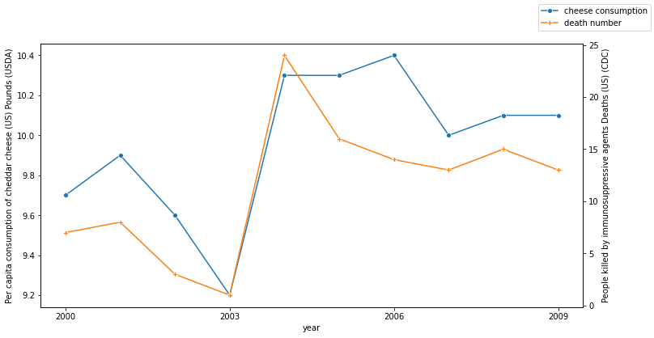

```python
# Create shorcuts for these very long labels
lab_cheese = "Per capita consumption of cheddar cheese (US) Pounds (USDA)"
lab_death = "People killed by immunosuppressive agents Deaths (US) (CDC)"

# Check for mispellings
assert lab_cheese in data.columns
assert lab_death in data.columns

# Create the figure and axis
fig, ax = plt.subplots(figsize=(12, 6))

# Create a line for the cheese consumption
sns.lineplot(x="year", y=lab_cheese, data=data, marker="o", color="C0",
             label="cheese consumption", ax=ax, legend=False)

# Create a duplicate of the axis for having a second y-axis
ax = ax.twinx()

# Create a line for the death number
sns.lineplot(x="year", y=lab_death, data=data, marker="P", color="C1",
             label="death number", ax=ax, legend=False)

# Make the legend
ax.figure.legend()

# Manually the placement of the x-axis ticks
plt.xticks(range(min(data["year"]), max(data["year"])+1, 3))

plt.show()
```

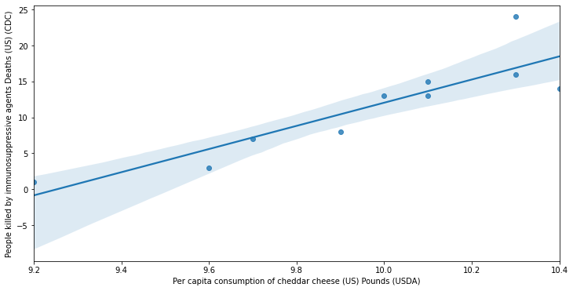

```python
# Create figure and axis
fig, ax = plt.subplots(figsize=(12, 6))

# Plot the linear regressioin
sns.regplot(x=lab_cheese, y=lab_death, data=data, ax=ax)

plt.show()
```

```python
# Compute the correlation coefficient
r, p = stats.pearsonr(data[lab_cheese], data[lab_death])

# Print the results
print(f"r = {r}, p = {p}")
```

```
r = 0.8835087706585109, p = 0.0006984113903627763
```

You can find a lot of surprising spurious correlations here (and also create your own): http://www.tylervigen.com/spurious-correlations

...so a good thing is to generally...

## Important

Check for **counfound** factors

[figure not shown]

## Important

Choose a **representation** adapted to the type of your data: **misrepresentations** leads to **misinterpreations**

Why is it important?

Let's take an example...

```python
# Import the data
df = pd.read_csv(os.path.join("data", "rr.csv"))

# Plot the top of the file
print(df.head())
```

```
     Country  Year        Debt    Growth
0  Australia  1946  190.419080 -3.557951
1  Australia  1947  177.321371  2.459475
2  Australia  1948  148.929811  6.437534
3  Australia  1949  125.828699  6.611994
4  Australia  1950  109.809398  6.920201
```

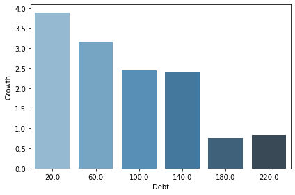

```python
# Create bins
df['DebtBin'] = pd.cut(df.Debt, bins=range(0, 250, 40), include_lowest=False)

# Compute the mean of each bins
y = df.groupby('DebtBin').Growth.mean()

# For the x-axis, compute the middle value of each bin
x = [i.left + (i.right - i.left)/2 for i in y.index.values]

# Create the barplot
ax = sns.barplot(x=x, y=y.values, palette="Blues_d")

# Set the axis labels
ax.set_xlabel("Debt")
ax.set_ylabel("Growth")

plt.tight_layout()
plt.show()
```

However, here is what the raw data look like:

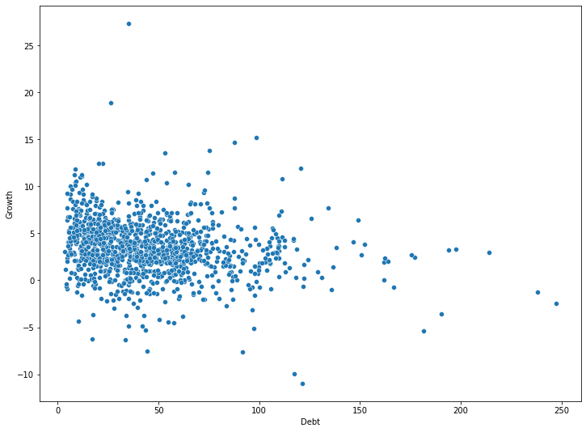

```python
# Create the figure and axis
fig, ax = plt.subplots(figsize=(12, 9))

# Plot a scatter instead
sns.scatterplot(x="Debt", y="Growth", data=df, ax=ax)
```

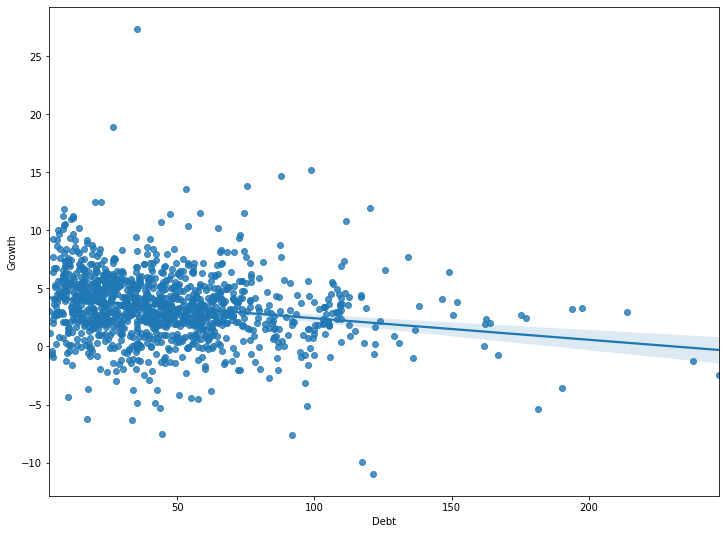

```python
# Create the figure and axis
fig, ax =plt.subplots(figsize=(12, 9))

# Plot a scatter plus a regression line
sns.regplot(x="Debt", y="Growth", data=df, ax=ax)

plt.show()
```

```python
# Compute the correlation coefficient
r, p = stats.pearsonr(df["Debt"], df["Growth"])

# Print the result
print(f"r = {r}, p={p}")
```

```
r = -0.19986576578883178, p=4.723997934448434e-12
```

However, to see if this result is really valid, we need to see extra stuff... Let's come back on this during the next lecture!

Adapted from the errors from [Reinhart, C. M., & Rogoff, K. S. (2010). Growth in a Time of Debt. American economic review, 100(2), 573-78.](https://pubs.aeaweb.org/doi/pdf/10.1257/aer.100.2.573) and the critic from https://scienceetonnante.com/2020/04/17/austerite-excel/ (in French) and corresponding GitHub repo: https://github.com/scienceetonnante/Reinhart-Rogoff.

To see a (serious) critique of this article: [Herndon, T., Ash, M., & Pollin, R. (2014). Does high public debt consistently stifle economic growth? A critique of Reinhart and Rogoff. Cambridge journal of economics, 38(2), 257-279.](https://www.peri.umass.edu/images/WP322.pdf)

One figure from the original paper:

[figure not shown]

## Important

In case of **tie**: Applying an **Occam's razor** is often a good strategy

For a contextualized explanation, you can refer to the [Stanford Encyclopedia](https://plato.stanford.edu/entries/simplicity/): Baker, Alan, "Simplicity", The Stanford Encyclopedia of Philosophy (Winter 2016 Edition), Edward N. Zalta (ed.), URL = https://plato.stanford.edu/archives/win2016/entries/simplicity/.

[figure not shown]

> Laplace went in state to Napoleon to present a copy of his work [...]. Someone had told Napoleon that the book contained no mention of the name of God; Napoleon [...] received it with the remark, 'M. Laplace, they tell me you have written this large book on the system of the universe, and have never even mentioned its Creator.' Laplace [...] answered bluntly, [...] **"I had no need of that hypothesis."**[...] Napoleon, greatly amused, told this reply to Lagrange, who exclaimed [...] "Ah, it is a fine hypothesis; it explains many things."

From [W.W. Rouse Ball A Short Account of the History of Mathematics, 4th edition, 1908](https://www.goodreads.com/book/show/2379465.A_Short_Account_of_the_History_of_Mathematics).

> If all of chemistry can be explained in a satisfactory manner without the help of phlogiston, that is enough to render it infinitely likely that the principle does not exist, that it is a hypothetical substance, a gratuitous supposition. It is, after all, a principle of logic not to multiply entities unnecessarily (Lavoisier 1862, pp. 623–4).

> [T]he grand aim of all science…is to cover the greatest possible number of empirical facts by logical deductions from the smallest possible number of hypotheses or axioms (Einstein, quoted in Nash 1963, p. 173).

Both quotations from the [Stanford Encyclopedia](https://plato.stanford.edu/entries/simplicity/).

### External validity

Course Overview

To go further on this, we need to first dive into inferential statistics, so more on this next week!

# Conclusive Remarks and a Few Takeaways

## Learning objectives

Learn by a series of examples the elementary rules of experimentation, and the main threats to validity